# R Módulo IV: Estadística

# Procesos estocásticos

Podemos generar un proceso Poisson, que cuenta el número de ocurrencias de un evento en el tiempo. Esto se relaciona con los tiempos exponenciales.

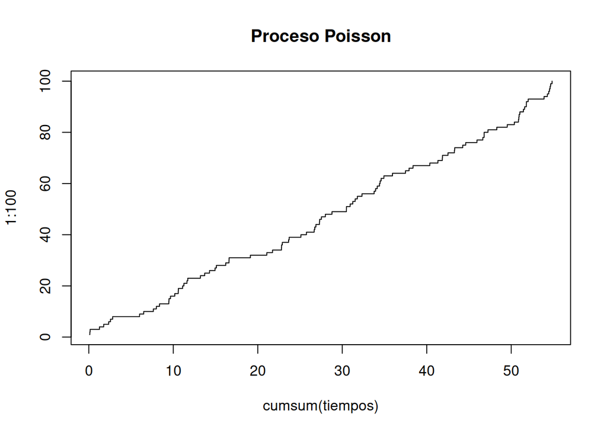

```r
set.seed(20) # fija una semilla aleatoria
tiempos <- rexp(100, rate = 2) # en promedio, ocurren 2 eventos por unidad de tiempo.
plot(cumsum(tiempos), 1:100,type="s", main = "Proceso Poisson")
```

Un ejemplo de un proceso Browniano (Robert Brown)

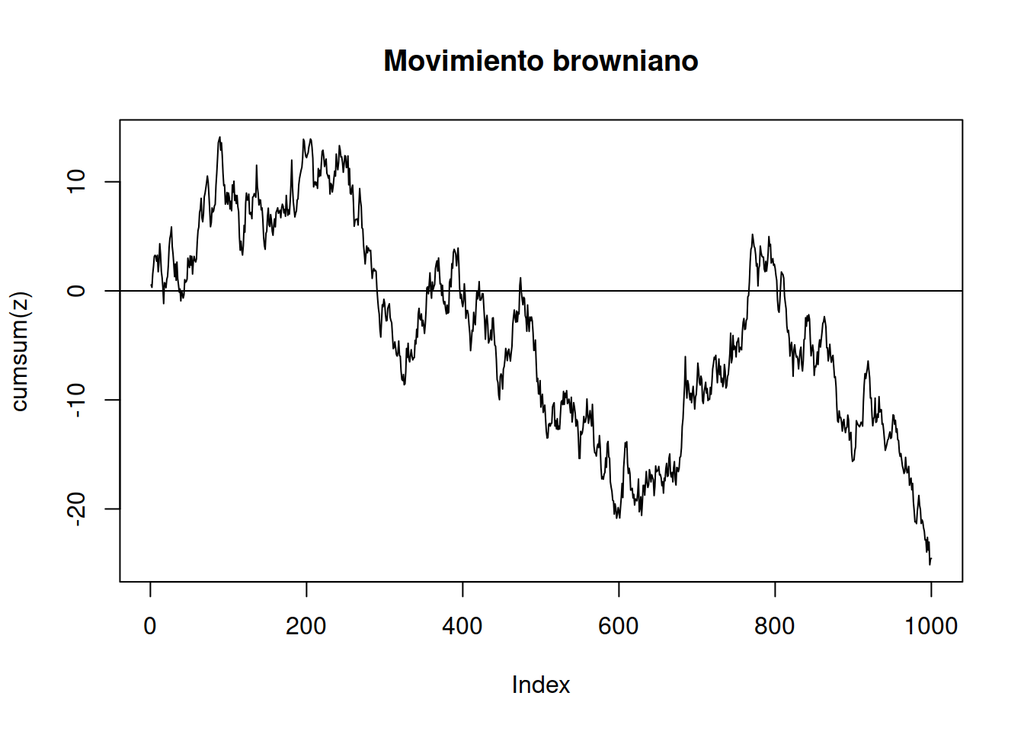

```r
z <- rnorm(1000)
plot(cumsum(z), type="l", main = "Movimiento browniano")
abline(h=0)  # agrega una linea horizontal
```

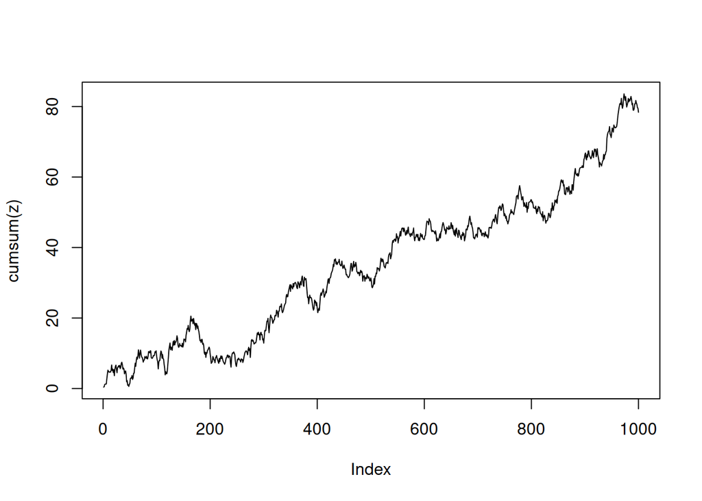

```r
# proceso con tendencia:
z <- 0.1 + rnorm(1000)
plot(cumsum(z),type="l")
```

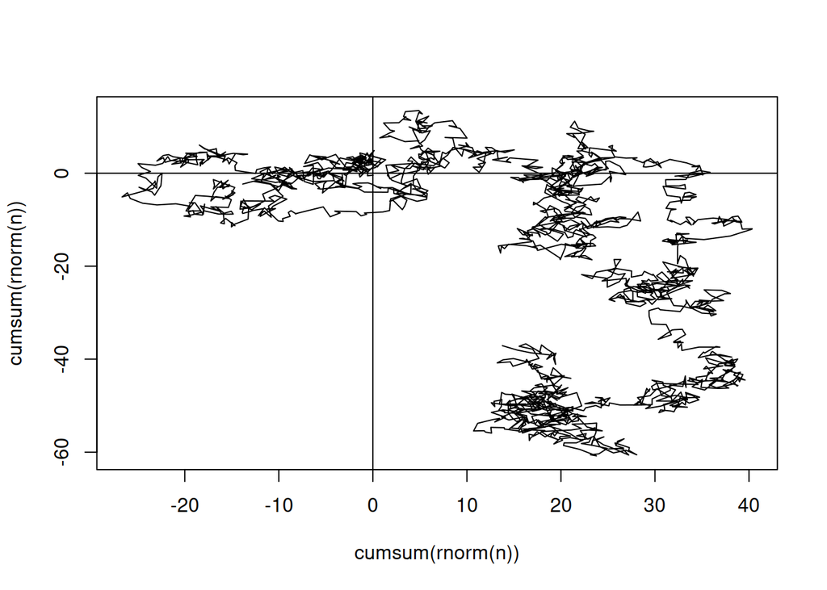

```r
# Movimiento browniano en el plano
n <- 2000
plot(cumsum(rnorm(n)), cumsum(rnorm(n)), type = "l")
abline(h=0,v=0)
```

Características de las poblaciones. Por ejemplo, cuantil de una distribución normal estándar (para no buscarlo en tablas) al 90%, 95% y 99%:

```r
qnorm(p = c(0.95,0.975,0.995), lower.tail = T)
```

```
[1] 1.644854 1.959964 2.575829
```

```r
qt(p = c(0.95,0.975, 0.995), df = 100, lower.tail = T)
```

```
[1] 1.660234 1.983972 2.625891
```

## Conteo: combinaciones y permutaciones, probabilidad condicional

Básicamente se tienen funciones de conteo que pueden usarse para calcular ciertas probabilidades:

```r
choose(10, 5)  # Cuantos subconjuntos de tamaño 5 se pueden hacer con 10 elementos
```

```
[1] 252
```

```r
factorial(10)  # 10! = 10*9*8*7*6*5*4*3*2*1
```

```
[1] 3628800
```

## Medidas de tendencia central

Cuando se vieron las estadísticas sumarias, vimos algunas de estas medidas. Además de la media, la mediana, y la moda, hay otras medidas de tendencia central que se pueden usar en diferentes contextos

```r
x <- datos$platelets
mean(x)
```

```
[1] 263358
```

```r
median(x)
```

```
[1] 262000
```

```r
# No hay una función para la moda, podemos hacer la nuestra. Esta puede funcionar para categorías o números discretos
moda <- function(x){
        u <- unique(x)
        u[which.max(tabulate(match(x,u)))]
}
# Ejmplo de aplicación de la función anterior:
moda(datos$platelets)
```

```
[1] 263358
```

```r
moda(datos$gedad)
```

```
[1] adulto
Levels: joven < adulto < senil
```

```r
moda(c(1,2,3,42,2,2,3,2,1,3,2,2,2,2,3,4,5,5))
```

```
[1] 2
```

```r
# media recortada
mean(x,trim = 0.10) # corta 10% de las observaciones de cada cola (10% abajo y 10% arriba, 20% en total)
```

```
[1] 256730.1
```

## Medidas de dispersión

Aquí podemos agregar el coeficiente de variación, que es la desviación estándar entre la media, que nos dice qué tan grende es la desviación estándar con respecto a la media.

```r
(cv <- sd(x)/mean(x))      # coeficiente de variación
```

```
[1] 0.3713737
```

```r
(rango <- max(x) - min(x)) # rango
```

```
[1] 824900
```

```r
mad <- mean(abs(x-mean(x))) # desviación media absoluta. Se usa mucho como medida de error en los pronósticos
```

## Teorema central del límite

Un ejercicio sencillo para probar el teorema del límite central. La idea es probar que el promedio de cualquier variable aleatoria sigue una distribución normal cuando el tamaño de muestra es muy grande

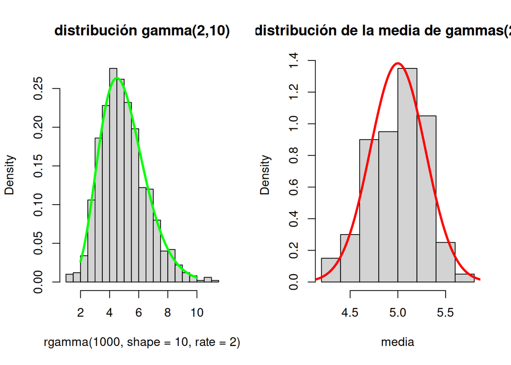

```r
TLC <- function(n,k){
# n es el tamaño de muestra, y k es el número de simulaciones que se repetirá el ejercicio para calcular
# el histograma de la media de los n datos.
media <- numeric(k) # donde vamos a guardar las medias
for(i in 1:k){
  X <- rgamma(n, shape=10, rate = 2)
  media[i] <- mean(X)
}
par(mfrow=c(1,2))
hist(rgamma(1000, shape=10,rate = 2), breaks = 30, prob = T, main = "distribución gamma(2,10)")
lines(seq(2,10,length=1000),dgamma(seq(2,10,length=1000), shape=10, rate = 2), col ="green", lwd=3)
hist(media, breaks = min(n/5,100), prob=T, main = "distribución de la media de gammas(2,10)")
lines(seq(4,6,length=1000),dnorm(seq(4,6,length=1000),mean=10/2,sd=sqrt(10/4/n)),col="red",lwd=3)
}

TLC(30,100)
```

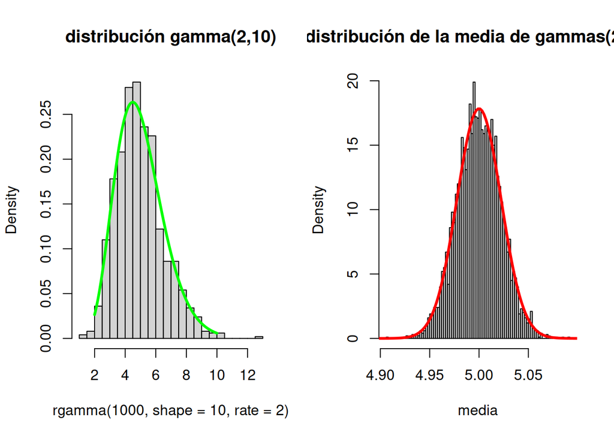

```r
TLC(5000,5000)
```

## Intervalos y pruebas de hipótesis

Supóngan que queremos probar que las proporciones de muertes son iguales para hombres y mujeres. Podemos hacer lo siguiente:

```r
xtabs(DEATH_EVENT ~ sex, data=datos)
```

```
sex
 0  1
34 62
```

```r
n <- length(datos$DEATH_EVENT)
prop.test(x = c(34,62), n = c(n,n), alternative = "two.sided")
```

```
    2-sample test for equality of proportions with continuity correction

data:  c(34, 62) out of c(n, n)
X-squared = 9.0459, df = 1, p-value = 0.002633
alternative hypothesis: two.sided
95 percent confidence interval:
 -0.15535492 -0.03193605
sample estimates:
   prop 1    prop 2
0.1137124 0.2073579
```

```r
prop.test(x = c(7,155,137), n = c(n,n,n), alternative = "two.sided")
```

```
    3-sample test for equality of proportions without continuity correction

data:  c(7, 155, 137) out of c(n, n, n)
X-squared = 196.29, df = 2, p-value < 2.2e-16
alternative hypothesis: two.sided
sample estimates:
    prop 1     prop 2     prop 3
0.02341137 0.51839465 0.45819398
```

```r
prop.test(x = 34, n = n, p = 0.1, alternative = "greater")
```

```
    1-sample proportions test with continuity correction

data:  34 out of n, null probability 0.1
X-squared = 0.48161, df = 1, p-value = 0.2438
alternative hypothesis: true p is greater than 0.1
95 percent confidence interval:
 0.08544834 1.00000000
sample estimates:
        p
0.1137124
```

Para probar igualdad de medias:

```r
a <- tapply(datos$creatinine_phosphokinase, datos$diabetes,mean)
b0 <- datos$creatinine_phosphokinase[datos$diabetes==0]
b1 <- datos$creatinine_phosphokinase[datos$diabetes==1]
t.test(x = b0, y = b1, alternative = "two.sided",conf.level = 0.95)
```

```
    Welch Two Sample t-test

data:  b0 and b1
t = 0.16913, df = 282.87, p-value = 0.8658
alternative hypothesis: true difference in means is not equal to 0
95 percent confidence interval:
 -201.3689  239.2266
sample estimates:
mean of x mean of y
 589.7529  570.8240
```

```r
# También podemos usar la notación de modelos
t.test(creatinine_phosphokinase ~ diabetes, data = datos, conf.level = 0.99)
```

```
    Welch Two Sample t-test

data:  creatinine_phosphokinase by diabetes
t = 0.16913, df = 282.87, p-value = 0.8658
alternative hypothesis: true difference in means between group 0 and group 1 is not equal to 0
99 percent confidence interval:
 -271.3103  309.1681
sample estimates:
mean in group 0 mean in group 1
       589.7529        570.8240
```

Si queremos probar que es igual una de ellas a un valor específico:

```r
t.test(x = b0, mu = 600)
```

```
    One Sample t-test

data:  b0
t = -0.13323, df = 173, p-value = 0.8942
alternative hypothesis: true mean is not equal to 600
95 percent confidence interval:
 437.9428 741.5629
sample estimates:
mean of x
 589.7529
```